# Tendência e Sazonalidade

.

# Séries Temporais

#### Igor Kuivjogi / Kaíque Ferreira / Nilo Célio

#### **1° Trablho de Séries Temporais**

##### 07 de Julho de 2020

.

# Tendência

Neste trabalho veremos as três seguintes formas de retirar a tendência de um série temporal

- Diferenciação
- Médias Móveis
- Lowess
- Médias Móveis VS Lowess

### Diferenciação

Aplicaremos diferenciação no histórico do IBOVESPA nas seguintes variáveis

- Temos 1499 observações
- Data: Dias 3 de janeiro de 1995 a 27 de dezembro de 2000
- Pontos do índice IBOVESPA diário

Vejamos a série de dados:

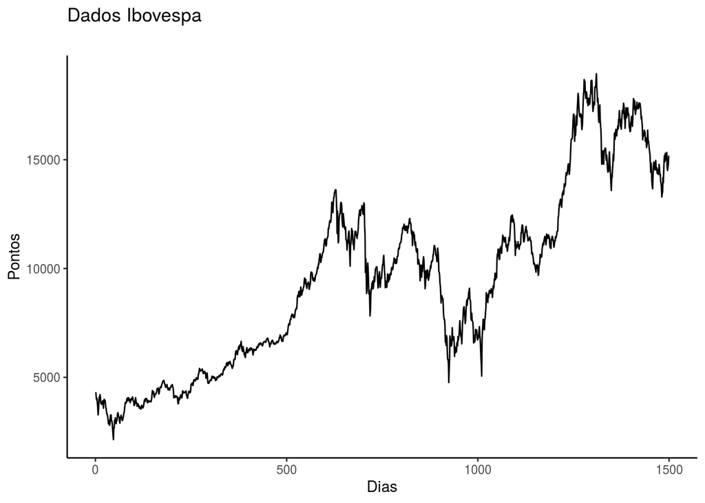

Agora vamos identificar a diferença entre uma, quatro e sete diferenciações

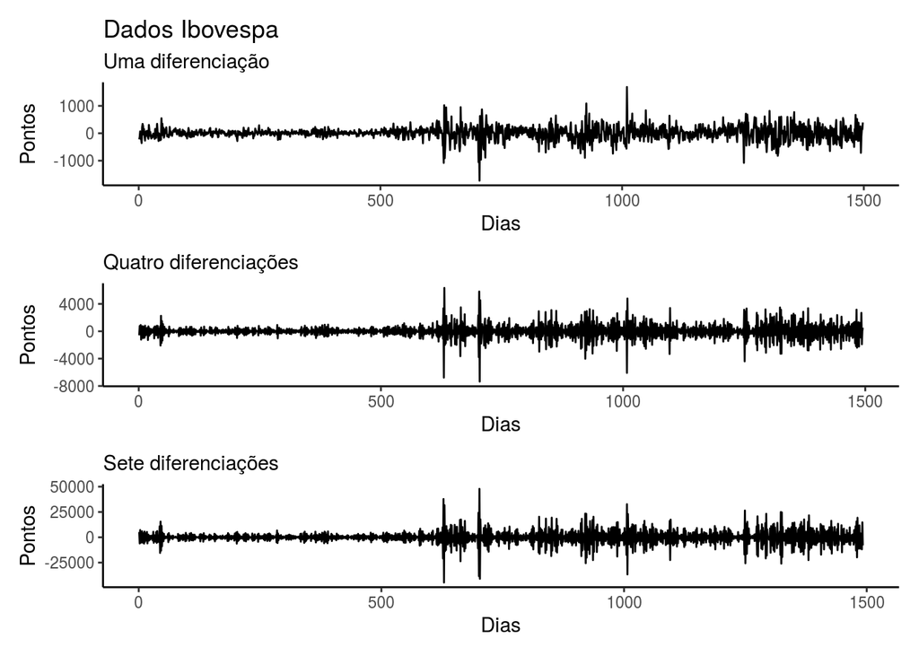

### Médias Móveis

Vejamos a série de dados e as médias móveis de terceira ordem:

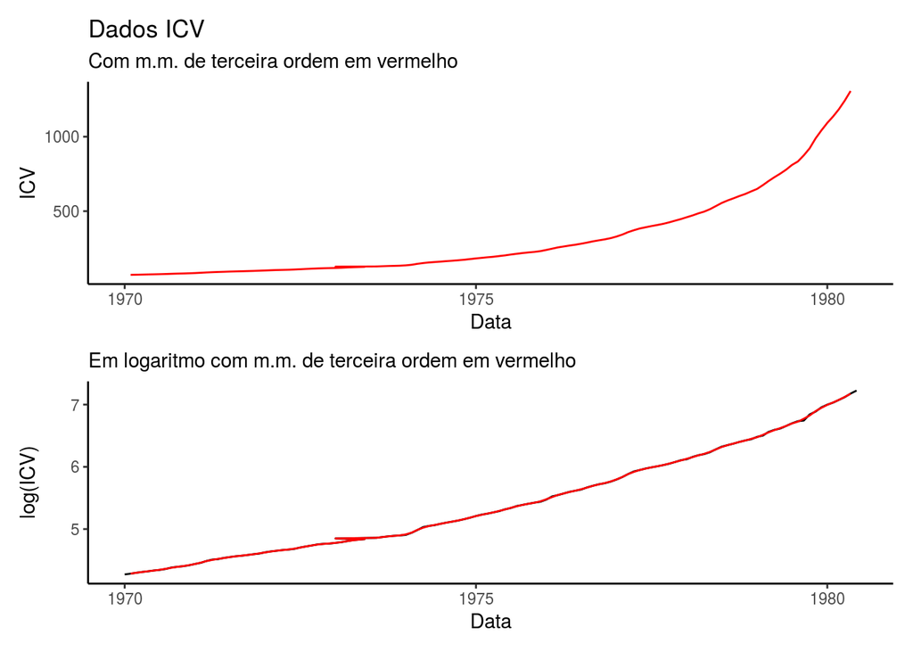

Tentaremos retirar a tendência a partir do ajuste de médias móveis de terceira ordem, exploremos os resultados

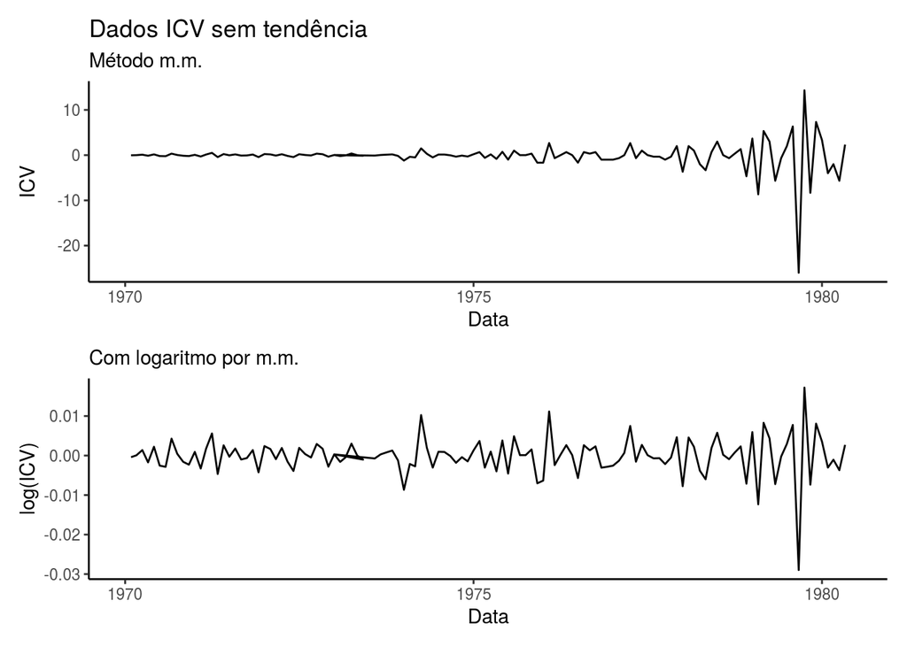

### Lowess

Vamos aplicar o método Lowess com p = 0,08 no mesmo conjunto de dados para comparar os resultados

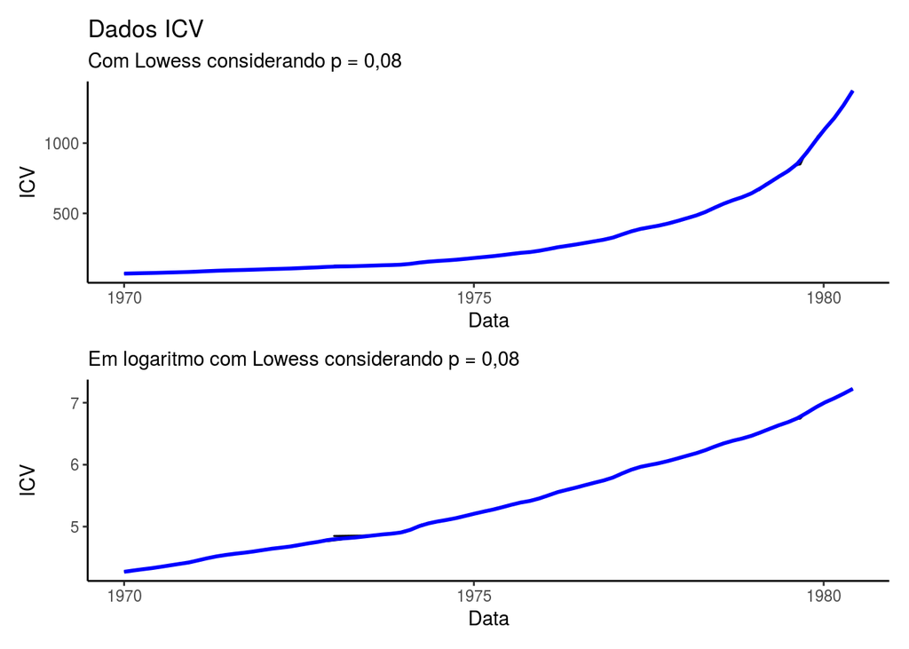

Tentaremos retirar a tendência a partir do ajuste do método Lowess considerando p = 0,08, exploremos os resultados

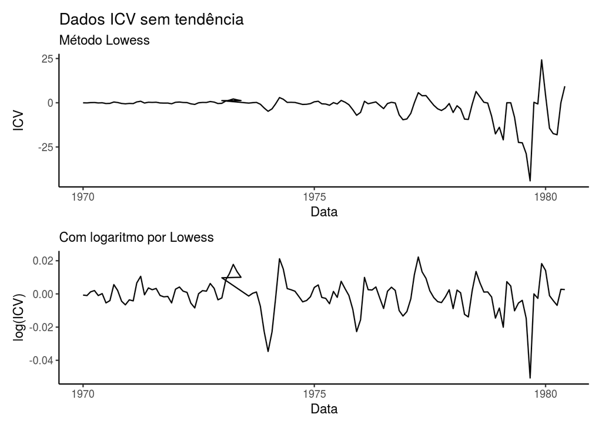

### Médias Móveis VS Lowess

Vamos explorar esses gráficos que comparam as médias móveis de terceira ordem e o método Lowess com p = 0,08

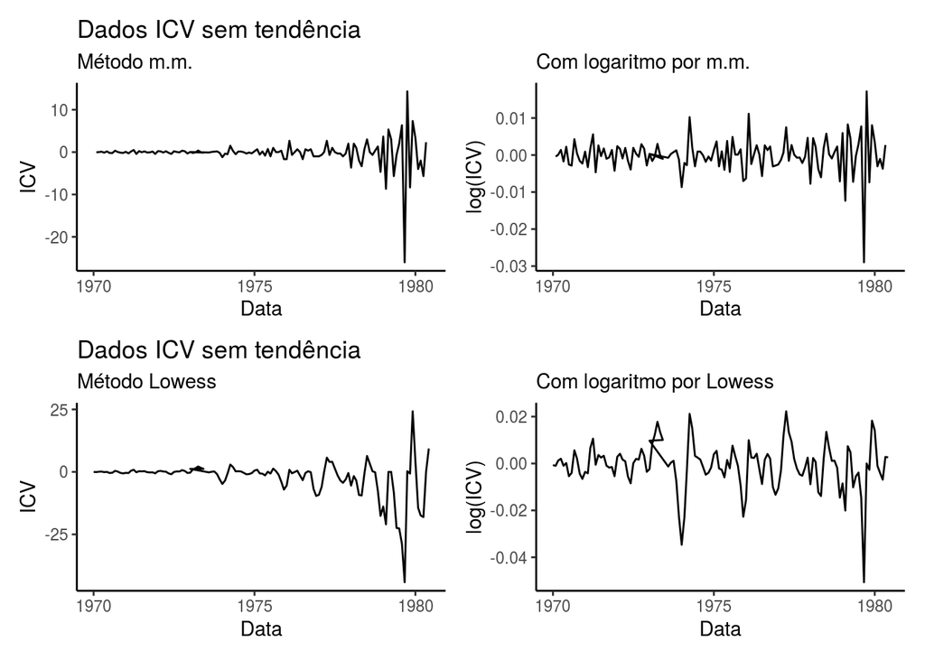

Nesse gráfico abaixo conseguimos ver de forma bem mais clara como é a construção das médias móveis em um conjunto de dados referente a produção física industrial nas seguintes variáveis:

- Produção física industrial total mensal
- Data: Mês de janeiro de 1991 a julho de 2000

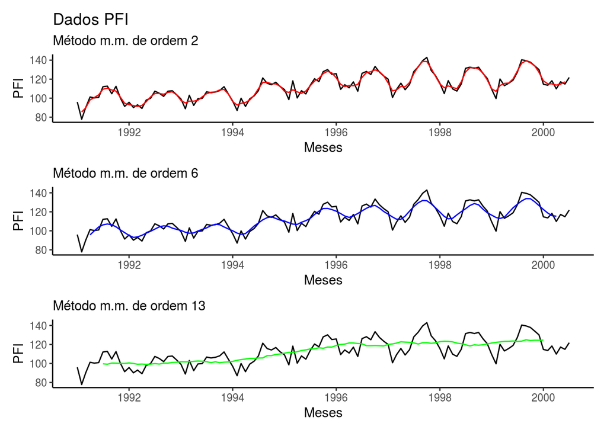

Nesse gráfico abaixo conseguimos ver de forma bem mais clara como é a construção do método Lowess utilizando o mesmo conjunto de dados PFI

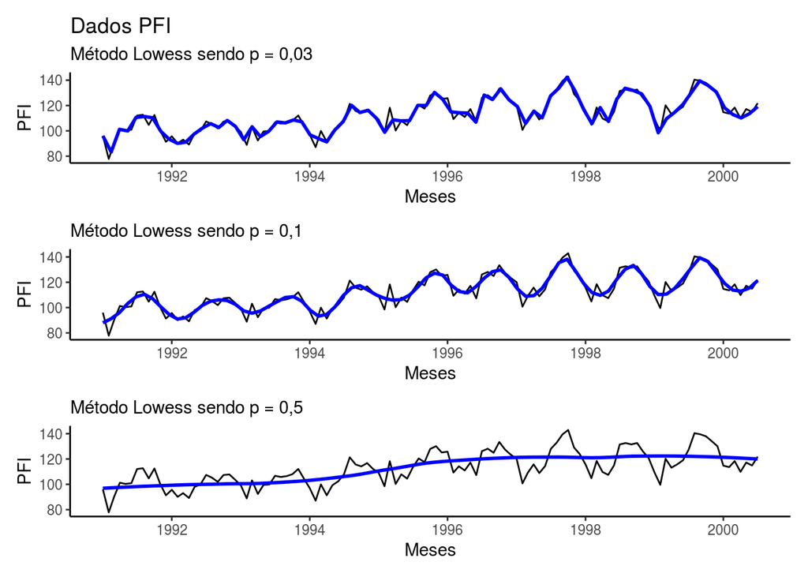

# Sazonalidade

### Manchas solares de Wolf

```
##       Ano          manchas           tempo
##  Min.   :1749   Min.   :  0.10   Min.   :  1.00
##  1st Qu.:1793   1st Qu.: 14.12   1st Qu.: 44.75
##  Median :1836   Median : 39.55   Median : 88.50
##  Mean   :1836   Mean   : 44.76   Mean   : 88.50
##  3rd Qu.:1880   3rd Qu.: 63.77   3rd Qu.:132.25
##  Max.   :1924   Max.   :154.40   Max.   :176.00
```

Temos uma série temporal compreendida entre 1749 a 1924 (176 anos).

### Número de Wolf

O número de Wolf (também conhecido como número internacional de mancha solar, número relativo de mancha solar ou número de Zurique) é um valor que indica o número de manchas solares e grupos de manchas solares presentes na superfície do Sol.  
A ideia de calcular o número de manchas solares se origina em Rudolf Wolf, em 1848, em Zurique, Suíça.  
**Fonte**: https://pt.wikipedia.org/wiki/N%C3%BAmero_de_Wolf

### Gŕafico da série temporal

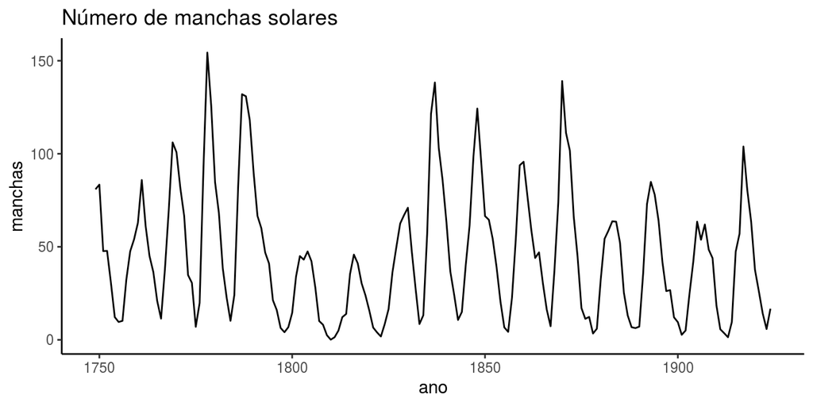

É possível notar que há uma certa sazonalidade, porém não parece haver tendência na série temporal.  
Vamos tentar modelar a componente de sazonalidade.

### Média móvel de ordem 3

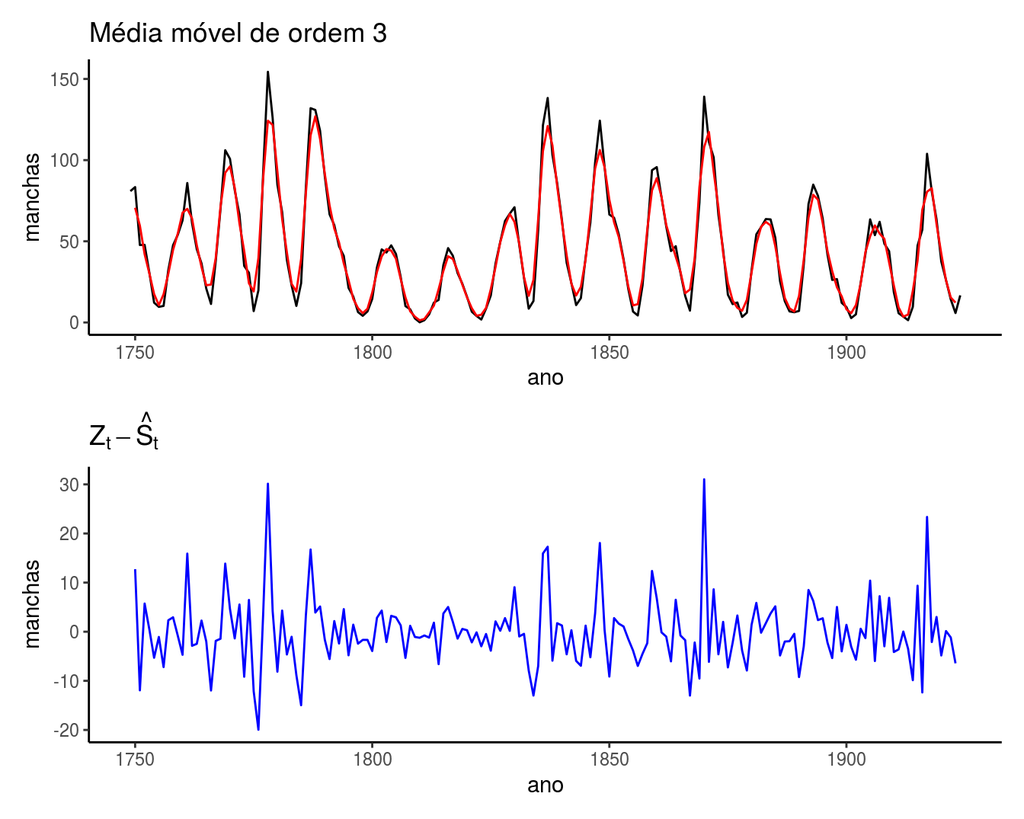

### Modelo LOWESS para p = 0.03

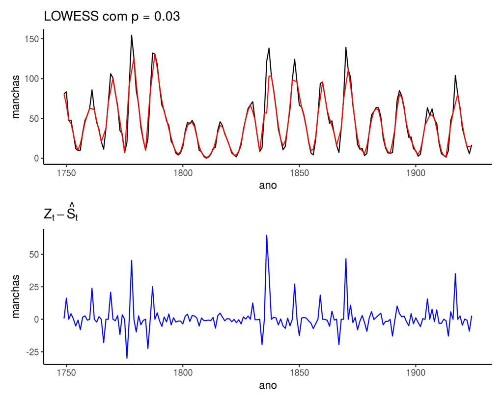